# Regressions

Tianran Zhang

6/20/2020

```r
load("../Data/ESP_reg.RData")
load("../Data/PIAAC_reg.RData")
```

# Empire State Poll (ESP)

## Investigate the association between numeracy and self-reported health status

- Outcome: binary health status
1. Original Levels (Multi-level/Excellent/Very good/Good/Fair/Poor/Unknown)
2. Health status (Binary): Good VS. Not Good
- Predictor: numeracy score
- Covariates: gender, age, education, income, race, ethincity
- Interaction term: education & numeracy score

### Univariate Regressions

```r
univ <- function(var, y, dat){
  form = formula(paste0(y, " ~ ", var))
  logit = glm(form, data = dat, family = "binomial")
  OR = data.frame(exp(cbind(OR = coef(logit), confint(logit))))[-1, ]
  OR = cbind(var, OR, coef(summary(logit))[-1, 4])
  colnames(OR) <- c("Covariate", "OR", "2.5%", "97.5%", "p-val")
  OR$sig <- ifelse(OR$`p-val` < 0.05, "*", "")
  return(OR)
}

varlist1 <- c("numeracy", "gender", "age.cat", "educ",
              "income.cat", "race", "hisp")
univ_summary1 <- do.call(rbind.data.frame,
                        lapply(varlist1, univ,
                               y = "health_status_good",
                               dat = ESP.reg))
univ_summary1 %>%
  kable() %>%
  kable_styling()
```

Covariate

OR

2.5%

97.5%

p-val

sig

numeracy

numeracy

1.1310087

1.0745536

1.1907181

0.0000024

genderFemale

gender

1.1223249

0.7865289

1.6043380

0.5251103

age.cat21-44

age.cat

0.3344498

0.0788065

0.9684247

0.0764244

age.cat45-64

age.cat

0.3452012

0.0811972

1.0029841

0.0859788

age.cat65+

age.cat

0.2148103

0.0501016

0.6340164

0.0139635

educSome college or associate’s degree

educ

2.6327787

1.6722560

4.1862792

0.0000343

educBachelor’s degree or higher

educ

4.5096573

2.9231403

7.0190585

0.0000000

income.cat$50k-$100k

income.cat

3.3088235

2.1361507

5.2205767

0.0000001

income.cat$100k-$150k

income.cat

2.5277778

1.4579345

4.5790464

0.0014129

income.cat$150k+

income.cat

3.9687500

2.2711314

7.3259279

0.0000035

raceBlack

race

0.5924866

0.3622596

0.9917385

0.0409053

raceOther

race

0.6859097

0.4422673

1.0816513

0.0975630

hispNon-hispanic

hisp

1.9029966

1.2114110

2.9442392

0.0044069

```r
sig.var <- univ_summary1 %>%
  filter(`p-val` < 0.05) %>%
  select(Covariate)
sig.var <- unique(sig.var$Covariate)
```

Based on the summary table above, 6 variables are significant covariates of people’s health status numeracy, age.cat, educ, income.cat, race, hisp.

### Multivariate Regressions

```r
n <- nrow(ESP.reg)

set.seed(135)
id <- sample(n, n * .6)
ESP.training <- ESP.reg[id, ]
ESP.test <- ESP.reg[-id, ]
```

**Unweighted Regressions**

```r
ESP.reg$health_status_good <- relevel(ESP.reg$health_status_good,
                                      ref = "Good")
full1 <- glm(health_status_good ~ numeracy + gender + age.cat +
               educ + income.cat + race + hisp+
               educ:numeracy, data = ESP.reg, family = "binomial")
final1 <- step(full1, direction = "both", trace = 0)
# summary(final1)
fit1 <- glm(health_status_good ~ numeracy + age.cat + educ +
              income.cat, data = ESP.reg, family = "binomial")

multi_summary1 <- exp(cbind(coef(fit1), confint(fit1))[-1, ]) %>% as.data.frame()
colnames(multi_summary1)[1] <- "OR"
multi_summary1$sig <- ifelse(summary(fit1)$coefficients[-1, 4] < 0.05, "*", "")

kable(multi_summary1) %>%
  kable_styling()
```

OR

2.5 %

97.5 %

sig

numeracy

0.9408120

0.8880810

0.9970226

age.cat21-44

4.8248533

1.6023285

20.9627085

age.cat45-64

4.8759895

1.6120494

21.2295048

age.cat65+

6.8626507

2.2310924

30.1657798

educSome college or associate’s degree

0.4335870

0.2659279

0.7014795

educBachelor’s degree or higher

0.3001718

0.1824655

0.4910541

income.cat$50k-$100k

0.4206950

0.2599475

0.6717320

income.cat$100k-$150k

0.6383839

0.3390678

1.1620431

income.cat$150k+

0.4570530

0.2344569

0.8557625

```r
# power calculation
power1 <- powerSim(final1, nsim = 100,  progress = FALSE)
auc1 <- auc(ESP.reg$health_status_good, predict.glm(fit1, ESP.reg, type = "response"))

# Calculate error rate
fit1.train <- glm(health_status_good ~ numeracy + age.cat + educ +
              income.cat, data = ESP.training, family = "binomial")
pred1 <- predict(fit1.train, ESP.test, type = "response")
pred1 <- ifelse(pred1 > .5, "Good", "Not Good")
err1 <- mean(pred1 != ESP.test$health_status_good)
```

Step-wise selection method was conducted. The final model has four significant predictors: numeracy, age, education, and income. The power for our final model is 0.81, with an AUC of 0.7237434. The prediction error rate is 0.219.

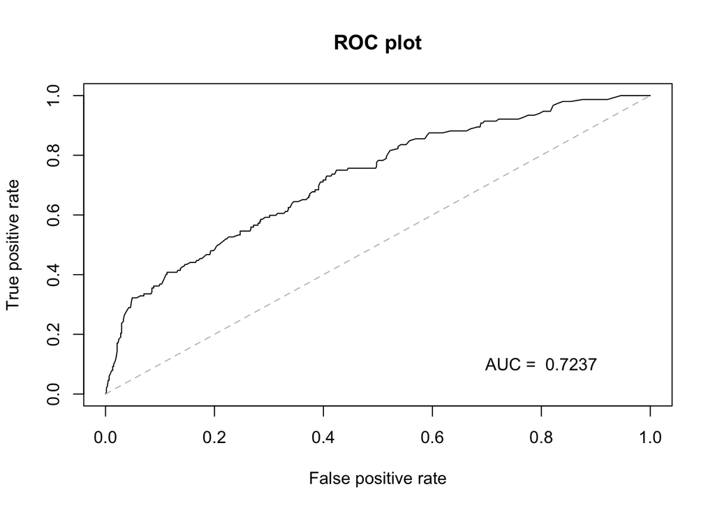

```r
# ROC curve
rocplot <- function(truth, pred, ...){
  predob = prediction(pred, truth)
  perf = performance(predob, "tpr", "fpr")
  plot(perf, colorize=F, ...)
  area = auc(truth, pred)
  area = format(round(area, 4), nsmall = 4)
  text(x = .8, y = .1, labels = paste("AUC = ", area))
  segments(x0 = 0, y0 = 0, x1 = 1, y1 = 1, col = "gray", lty = 2)
}

rocplot(ESP.reg$health_status_good, predict.glm(fit1, ESP.reg, type = "response"), title = "ROC plot")
title(main = "ROC plot")
```

**Weighted Regressions**  
Based on the comparison table between ESP and NYS, education, income and race are three variables that have different different distributions in ESP data and NYS dataset. Add weights to adjust the proportion of these three variables and refit the multi-regression model, education and income are significant covariates. So, we only add weights to adjust the proportion of education and income. Weights are calculated based on manual iterative solution.

```r
# This function generate survey weights automatically
surv.wt <- function(x, w, col_name){
  # x: dataset of interest
  # w: NYS percentages
  # cpl_pos: column number of the variable to be weighted
  # col_name: name of the variable to be weighted
  #x <- ESP.weighted; w <- wt.edu; col_pos<- 5; col_name <- "educ"
  col_pos <- which(colnames(x) == col_name)
  x1 <- x %>%
    group_by_at(col_pos) %>%
    summarise(wt = sum(wt)/nrow(x)) %>%
    mutate(wt_new = w/wt) %>%
    select(-wt)

  merge(x, x1, by = col_name) %>%
    mutate(wt = wt * wt_new) %>%
    select(-wt_new)
}

# This function check if weighted ESP is significant different
# compared to NYS

fisher.sig <- function(x, col_name, w2){
  col_pos <- which(colnames(x) == col_name)
  x1 <- x %>%
    group_by_at(col_pos) %>%
    summarise(w = sum(wt))
  fisher.test(matrix(c(x1$w, w2), byrow = T, ncol = length(w2)),
              simulate.p.value = T)$p.value
}
```

```r
# Manully input the NYS education level proportion and hispanic proportion

ESP.weighted <- ESP.reg %>%
  mutate(wt = 1)

wt.educ <- c(97506, 69577, 83478)
wt.income <- c(51303, 64932, 19158, 19930)
wt.race <- c(13559, 3424, 2471)

# 1st iterative
ESP.weighted <- surv.wt(ESP.weighted, wt.educ/sum(wt.educ), "educ")
ESP.weighted <- surv.wt(ESP.weighted, wt.income/sum(wt.income), "income.cat")
# ESP.weighted <- surv.wt(ESP.weighted, wt.race/sum(wt.race), "race")

# Check p-values for fisher.tests
# fisher.sig(ESP.weighted, "educ", wt.educ)
# fisher.sig(ESP.weighted, "income.cat", wt.income)
# fisher.sig(ESP.weighted, "race", wt.race)
```

```r
full2 <- glm(health_status_good ~ numeracy + gender + age.cat +
               educ + income.cat + race + hisp, weights = wt,
             data = ESP.weighted, family = "binomial")
final2 <- step(full2, direction = "both", trace = 0)

fit2 <- glm(health_status_good ~ numeracy + age.cat +
               educ + income.cat +hisp, weights = wt,
             data = ESP.weighted, family = "binomial")
fit2.unweight <- glm(health_status_good ~ numeracy + age.cat +
               educ + income.cat +hisp,
               data = ESP.weighted, family = "binomial")

multi_summary2 <- exp(cbind(coef(fit2), confint(fit2))[-1, ]) %>% as.data.frame()
colnames(multi_summary2)[1] <- "OR"
multi_summary2$sig <- ifelse(summary(fit2)$coefficients[-1, 4] < 0.05, "*", "")

# power calculation
power2 <- powerSim(fit2, sim = fit2.unweight, nsim = 1000,
                   progress = FALSE)
auc2 <- auc(ESP.weighted$health_status_good, predict.glm(fit2, ESP.weighted, weights = wt, type = "response"))

kable(multi_summary2) %>%
  kable_styling()
```

OR

2.5 %

97.5 %

sig

numeracy

0.9250619

0.8757010

0.9768844

age.cat21-44

4.8866095

1.8648349

16.2931829

age.cat45-64

5.9164356

2.2453680

19.8101737

age.cat65+

7.2008336

2.6655593

24.4991061

educSome college or associate’s degree

0.5102401

0.3236786

0.7956869

educBachelor’s degree or higher

0.3587504

0.2144383

0.5895572

income.cat$50k-$100k

0.3873225

0.2511593

0.5927010

income.cat$100k-$150k

0.5552666

0.2866863

1.0326157

income.cat$150k+

0.4489146

0.2128162

0.8924817

hispNon-hispanic

0.5764680

0.3670891

0.9111345

```r
# lastResult()$error

# Calculate error rate
fit2.train <- glm(health_status_good ~ numeracy + age.cat +
               educ + income.cat +hisp, weights = wt,
             data = ESP.weighted[id, ], family = "binomial")
pred2 <- predict(fit2.train, ESP.test, type = "response")
pred2 <- ifelse(pred2 > .5, "Not Good", "Good")
err2 <- mean(pred2 != ESP.test$health_status_good)
```

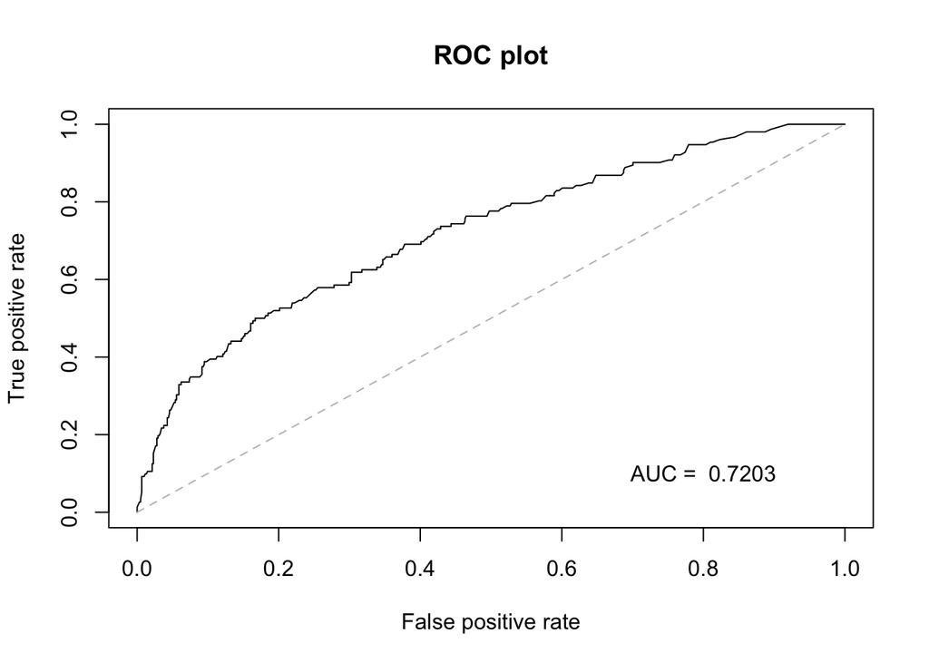

```r
# ROC curve
rocplot(ESP.weighted$health_status_good, predict.glm(fit2, ESP.weighted, weights = wt, type = "response"), title = "ROC plot")
title(main = "ROC plot")
```

## Investigate the association between numeracy and visits to doctors

- Outcome: binary visits to doctors
  1. Original Levels (Never/1-2 times/Once every few months/Once a month/Twice a month/Once a week/2-3 times a week)
  2. Visit status (Binary): Not often (#visits <=2) VS. Often (#visits >= 3)
- Predictor: numeracy score
- Covariates: egnder, age, education, income, race, ethincity

```r
table(ESP.reg$visits)
```

```
##
##                 Never             1-2 times Once every few months
##                    68                   223                   288
##          Once a month         Twice a month           Once a week
##                    96                    55                    23
##      2-3 times a week
##                    10
```

### Univariate Regressions

```r
univ_summary2 <- do.call(rbind.data.frame,
                        lapply(varlist1, univ,
                               y = "visits_often",
                               dat = ESP.reg))
sig.var2 <- univ_summary2 %>%
  filter(`p-val` < 0.05) %>%
  select(Covariate)
sig.var2 <- unique(sig.var2$Covariate)

univ_summary2 %>%
  kable() %>%
  kable_styling()
```

Covariate

OR

2.5%

97.5%

p-val

sig

numeracy

numeracy

1.0025433

0.9582304

1.048334

0.9116195

genderFemale

gender

1.5512637

1.1564097

2.085116

0.0034868

age.cat21-44

age.cat

1.5098947

0.7832396

2.935385

0.2187003

age.cat45-64

age.cat

2.0147368

1.0404744

3.935617

0.0378766

age.cat65+

age.cat

3.0526316

1.5116548

6.234887

0.0019222

educSome college or associate’s degree

educ

1.3674330

0.9136772

2.049649

0.1285991

educBachelor’s degree or higher

educ

1.9282828

1.3340132

2.790394

0.0004810

income.cat$50k-$100k

income.cat

1.4252585

1.0014677

2.032272

0.0495079

income.cat$100k-$150k

income.cat

1.3922022

0.8817811

2.216512

0.1586165

income.cat$150k+

income.cat

2.2384428

1.4449605

3.515331

0.0003718

raceBlack

race

0.6562184

0.4239745

1.020599

0.0595373

raceOther

race

0.5202694

0.3574367

0.756807

0.0006283

hispNon-hispanic

hisp

2.0112289

1.3545065

2.993148

0.0005379

### Multivariate Regressions

**Unweighted Regression**

```r
full3 <- glm(visits_often ~ numeracy + gender + age.cat +
               educ + income.cat + race + hisp,
             data = ESP.reg, family = "binomial")
final3 <- step(full3, direction = "both", trace = 0)
# summary(final3)
fit3 <- glm(visits_often ~ gender + age.cat + income.cat +
              hisp, data = ESP.reg, family = "binomial")

multi_summary3 <- exp(cbind(coef(fit3), confint(fit3))[-1, ]) %>% as.data.frame()
colnames(multi_summary3)[1] <- "OR"
multi_summary3$sig <- ifelse(summary(fit3)$coefficients[-1, 4] < 0.05, "*", "")

kable(multi_summary3) %>%
  kable_styling()
```

OR

2.5 %

97.5 %

sig

genderFemale

1.654164

1.2172931

2.254422

age.cat21-44

1.339225

0.6818388

2.647537

age.cat45-64

1.582724

0.7982824

3.154372

age.cat65+

2.529146

1.2249584

5.267092

income.cat$50k-$100k

1.461681

1.0135151

2.112951

income.cat$100k-$150k

1.452230

0.9042662

2.351546

income.cat$150k+

2.341435

1.4848887

3.741939

hispNon-hispanic

1.713213

1.1336185

2.591746

```r
# power calculation
power3 <- powerSim(fit3, nsim = 100,  progress = FALSE)
auc3 <- auc(ESP.reg$visits_often, predict.glm(fit3, ESP.reg, type = "response"))

# Calculate error rate
fit3.train <- glm(visits_often ~ gender + age.cat + income.cat +
              hisp, data = ESP.training, family = "binomial")
pred3 <- predict(fit3.train, ESP.test, type = "response")
pred3 <- ifelse(pred3 > .5, "Often", "Not Often")
err3 <- mean(pred3 != ESP.test$visits_often)
```

Step-wise selection method was conducted. The final model has four significant covariates: gender, age, income, and ethnicity. Numeracy is not a significant predictor. The power for our final model is 0.9, with AUC = 0.6427318. The prediction error rate is 0.35.

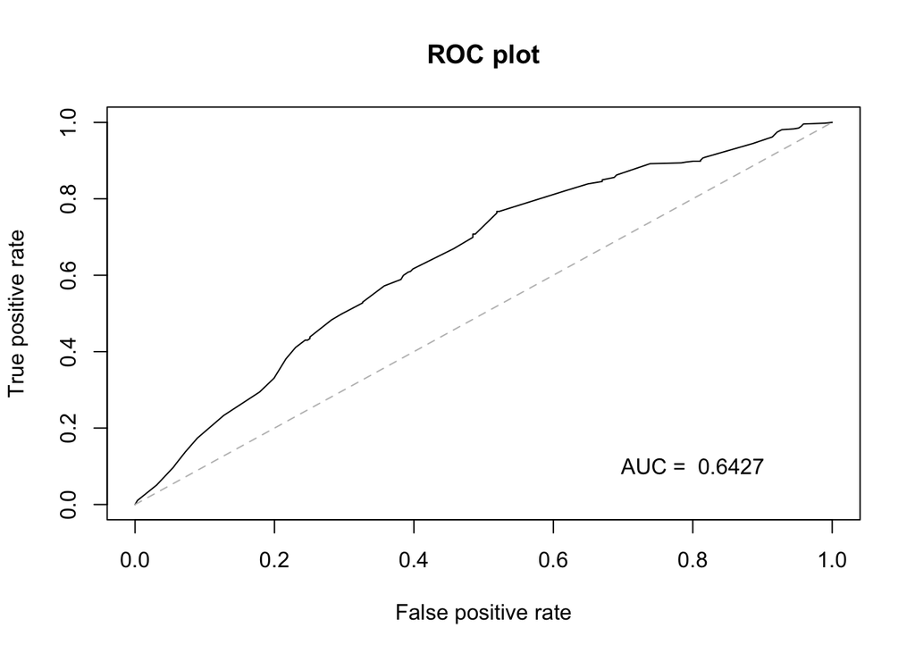

```r
# ROC curve
rocplot(ESP.reg$visits_often, predict.glm(fit3, ESP.reg, type = "response"), title = "ROC plot")
title(main = "ROC plot")
```

**Weighted Regressions**  
Based on the comparison table between ESP and NYS, education, income and race are three variables that have different different distributions in ESP data and NYS dataset. Add weights to adjust the proportion of these three variables and refit the multi-regression model, education and income are significant covariates. So, we only add weights to adjust the proportion of education and income. Weights are calculated based on manual iterative solution.

```r
# Manully input the NYS education level proportion and hispanic proportion
ESP.reg$visits_often <- relevel(ESP.reg$visits_often, ref = "Not Often")
ESP.weighted <- ESP.reg %>%
  mutate(wt = 1)

# 1st iterative
ESP.weighted <- surv.wt(ESP.weighted, wt.educ/sum(wt.educ), "educ")
ESP.weighted <- surv.wt(ESP.weighted, wt.income/sum(wt.income), "income.cat")
# ESP.weighted <- surv.wt(ESP.weighted, wt.race/sum(wt.race), "race")

# Check p-values for fisher.tests
# fisher.sig(ESP.weighted, "educ", wt.educ)
# fisher.sig(ESP.weighted, "income.cat", wt.income)
# fisher.sig(ESP.weighted, "race", wt.race)
```

```r
full4 <- glm(visits_often ~ numeracy + gender + age.cat +
               educ + income.cat + race + hisp, weights = wt,
             data = ESP.weighted, family = "binomial")
final4 <- step(full4, direction = "both", trace = 0)
# summary(final4)
fit4 <- glm(visits_often ~ gender + age.cat +
               educ + income.cat, weights = wt,
             data = ESP.weighted, family = "binomial")

multi_summary4 <- exp(cbind(coef(fit4), confint(fit4))[-1, ]) %>%
  as.data.frame()
colnames(multi_summary4)[1] <- "OR"
multi_summary4$sig <- ifelse(summary(fit4)$coefficients[-1, 4] < 0.05, "*", "")

auc4 <- auc(ESP.weighted$visits_often, predict.glm(fit4, ESP.weighted, weights = wt, type = "response"))
power4 <- powerSim(fit4, nsim = 100,  progress = FALSE)
kable(multi_summary4) %>%
  kable_styling()
```

OR

2.5 %

97.5 %

sig

genderFemale

1.564208

1.1524851

2.127981

age.cat21-44

1.170519

0.6418213

2.146915

age.cat45-64

1.667873

0.9107325

3.074277

age.cat65+

2.438784

1.2826310

4.679982

educSome college or associate’s degree

1.395754

0.9636915

2.027213

educBachelor’s degree or higher

1.540627

1.0472619

2.272132

income.cat$50k-$100k

1.436892

1.0075920

2.052647

income.cat$100k-$150k

1.293102

0.7775367

2.164771

income.cat$150k+

1.993067

1.1625325

3.470212

```r
# lastResult()$error

# Calculate error rate
fit4 <- glm(visits_often ~ gender + age.cat + educ + income.cat,
            weights = wt, data = ESP.weighted[id, ],
            family = "binomial")

pred4 <- predict(fit4, ESP.test, type = "response")
pred4 <- ifelse(pred4 > .5, "Often", "Not Often")
err4 <- mean(pred4 != ESP.test$visits_often)
```

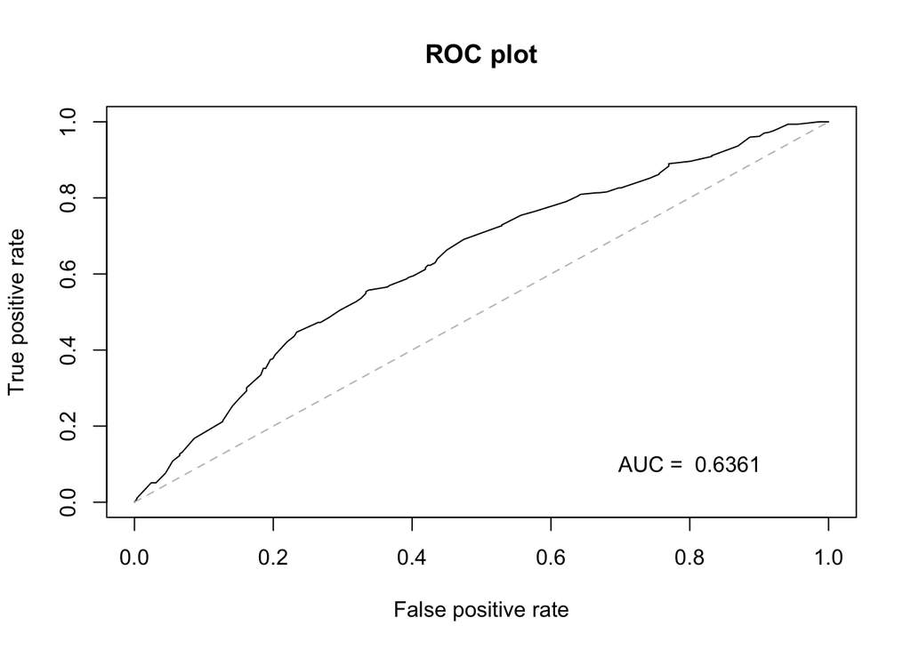

```r
# ROC curve
rocplot(ESP.weighted$visits_often,
        predict.glm(fit4, ESP.weighted, weights = wt,
                    type = "response"))
title(main = "ROC plot")
```

# PIAAC

Health status (Binary): Good VS. Not Good  
* Predictor: numeracy score  
* Covariates: education, income, race, ethincity  
* Additional predictors: literacy, problem solving

```r
n1 <- nrow(PIAAC.reg)
set.seed(135)
id1 <- sample(n1, n1 * .6)
PIAAC.training <- PIAAC.reg[id1, ]
PIAAC.test <- PIAAC.reg[-id1, ]
```

## Consider numeracy as the only predictor

```r
varlist2 <- c("numeracy", "educ", "income.cat", "race", "hisp",
              "literacy", "problem_solving")

full5 <- glm(health_status_good ~ numeracy + educ + income.cat +
               race + hisp, data = PIAAC.reg, family = "binomial")
final5 <- step(full5, direction = "both", trace = 0)
# summary(final5)
fit5 <- glm(health_status_good ~ numeracy + educ + income.cat,
            data = PIAAC.reg, family = "binomial")

multi_summary5 <- exp(cbind(coef(final5), confint(final5))[-1, ]) %>% as.data.frame()
colnames(multi_summary5)[1] <- "OR"
multi_summary5$sig <- ifelse(summary(final5)$coefficients[-1, 4] < 0.05, "*", "")

# power calculation
power5 <- powerSim(final5, nsim = 100, progress = FALSE)
auc5 <- auc(PIAAC.reg$health_status_good, predict.glm(final5, PIAAC.reg, type = "response", na.action = na.omit))
kable(multi_summary5) %>%
  kable_styling()
```

OR

2.5 %

97.5 %

sig

numeracy

0.9967733

0.9943513

0.9991954

educSome college or associate’s degree

0.7912688

0.5877246

1.0564039

educBachelor’s degree or higher

0.5998927

0.4408917

0.8116383

income.cat$50k-$100k

0.5408231

0.4142132

0.7027541

income.cat$100k-$150k

0.3253061

0.2065447

0.4947828

income.cat$150k+

0.3810627

0.2314980

0.6025915

```r
# Calculate error rate
fit5.train <- glm(health_status_good ~ numeracy + educ + income.cat,
            data = PIAAC.training, family = "binomial")
pred5 <- predict(fit5.train, PIAAC.test, type = "response")
pred5 <- ifelse(pred5 > .5, "Not Good", "Good")
err5 <- mean(pred5 != PIAAC.test$health_status_good)
```

Step-wise multivariate regression model was conducted on PIAAC data. The final model has three predictors :numeracy, education and income. The AUC is 0.6762154 with a power of 0.75. The prediction error rate is 0.148.

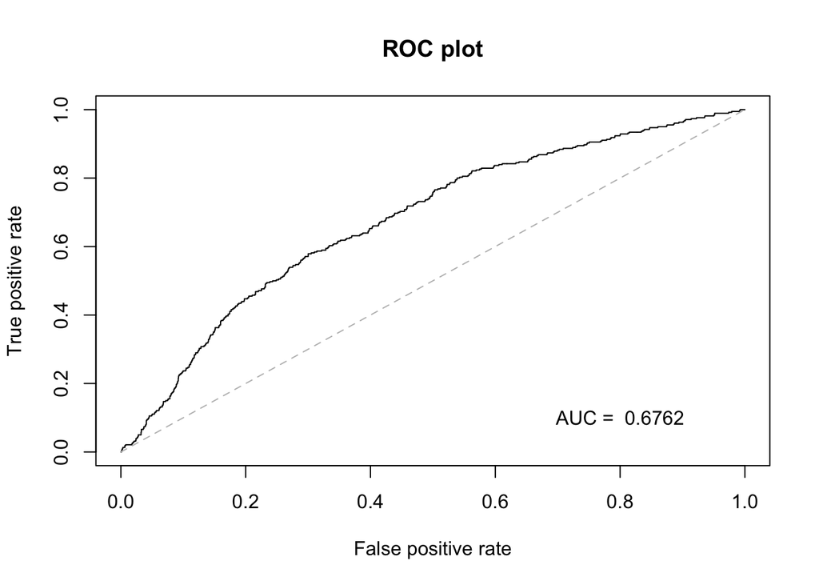

```r
# ROC curve
rocplot(PIAAC.reg$health_status_good, predict.glm(final5, PIAAC.reg, type = "response", na.action = na.omit), title = "ROC plot")
title(main = "ROC plot")
```

## Consider two additional predictors: Literacy and Problem solving abilities

```r
full6 <- glm(health_status_good ~ numeracy + educ + income.cat +
               race + hisp + literacy + problem_solving,
             data = PIAAC.reg, family = "binomial")
final6 <- step(full6, direction = "both", trace = 0)
fit6 <- glm(health_status_good ~ numeracy + educ + income.cat +
               problem_solving, data = PIAAC.reg,
            family = "binomial")
# summary(final6)
multi_summary6 <- exp(cbind(coef(final6), confint(final6))[-1, ]) %>%
  as.data.frame()
colnames(multi_summary6)[1] <- "OR"
multi_summary6$sig <- ifelse(summary(final6)$coefficients[-1, 4] < 0.05, "*", "")

# power calculation
power6 <- powerSim(final6, nsim = 100, progress = FALSE)
auc6 <- auc(PIAAC.reg$health_status_good, predict.glm(final6, PIAAC.reg, type = "response", na.action = na.omit))
kable(multi_summary6) %>%
  kable_styling()
```

OR

2.5 %

97.5 %

sig

numeracy

1.0048308

1.0009197

1.0087767

educSome college or associate’s degree

0.7797280

0.5778580

1.0433625

educBachelor’s degree or higher

0.5830349

0.4273816

0.7908966

income.cat$50k-$100k

0.5228163

0.3997012

0.6805468

income.cat$100k-$150k

0.3168319

0.2008163

0.4828411

income.cat$150k+

0.3618727

0.2192311

0.5740207

problem_solving

0.9888484

0.9846224

0.9930569

```r
# Calculate error rate
fit6.train <- glm(health_status_good ~ numeracy + educ + income.cat +
               problem_solving, data = PIAAC.training,
            family = "binomial")
pred6 <- predict(fit6.train, PIAAC.test, type = "response")
pred6 <- ifelse(pred6 > .5, "Not Good", "Good")
err6 <- mean(pred6 != PIAAC.test$health_status_good)
```

Step-wise multivariate regression model was conducted. The final model has four predictors: numeracy, educ, income and problem solving. The AUC is 0.6899707 with a power for numeracy of 0.77. The prediction error rate is 0.148.

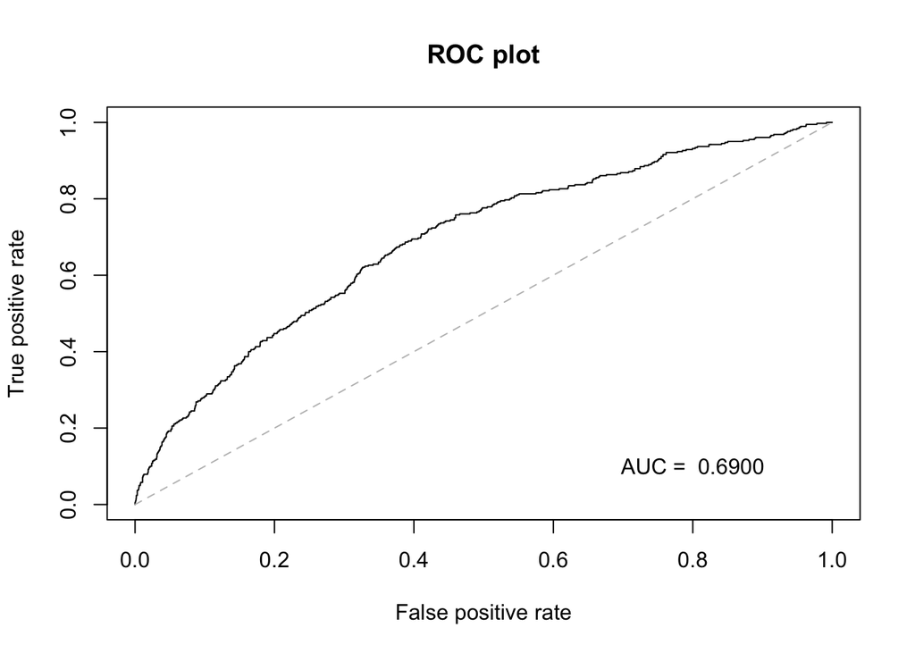

```r
rocplot(PIAAC.reg$health_status_good, predict.glm(final6, PIAAC.reg, type = "response", na.action = na.omit), title = "ROC plot")
title(main = "ROC plot")
```

## Consider numeracy1 as the only predictor

```r
varlist2 <- c("numeracy1", "educ", "income.cat", "race", "hisp",
              "literacy1", "problem_solving1")

full7 <- glm(health_status_good ~ numeracy1 + educ + income.cat +
               race + hisp, data = PIAAC.reg, family = "binomial")
final7 <- step(full7, direction = "both", trace = 0)
# summary(final7)
fit7 <- glm(health_status_good ~ numeracy1 + educ + income.cat,
            data = PIAAC.reg, family = "binomial")

multi_summary7 <- exp(cbind(coef(final7), confint(final7))[-1, ]) %>% as.data.frame()
colnames(multi_summary7)[1] <- "OR"
multi_summary7$sig <- ifelse(summary(final7)$coefficients[-1, 4] < 0.05, "*", "")

# power calculation
power7 <- powerSim(final7, nsim = 100, progress = FALSE)
auc7 <- auc(PIAAC.reg$health_status_good, predict.glm(final7, PIAAC.reg, type = "response", na.action = na.omit))
kable(multi_summary7) %>%
  kable_styling()
```

OR

2.5 %

97.5 %

sig

numeracy1

0.9963581

0.9937650

0.9989495

educSome college or associate’s degree

0.7992472

0.5932393

1.0678821

educBachelor’s degree or higher

0.6116115

0.4482334

0.8299643

income.cat$50k-$100k

0.5428745

0.4157468

0.7055039

income.cat$100k-$150k

0.3287606

0.2086143

0.5003944

income.cat$150k+

0.3855994

0.2340936

0.6102763

```r
# Calculate error rate
fit7.train <- glm(health_status_good ~ numeracy1 + educ + income.cat,
            data = PIAAC.training, family = "binomial")
pred7 <- predict(fit7.train, PIAAC.test, type = "response")
pred7 <- ifelse(pred7 > .5, "Not Good", "Good")
err7 <- mean(pred7 != PIAAC.test$health_status_good)
```

Step-wise multivariate regression model was conducted on PIAAC data. The final model has three predictors :numeracy1, education and income. The AUC is 0.6767444 with a power of 0.75. The prediction error rate is 0.148.

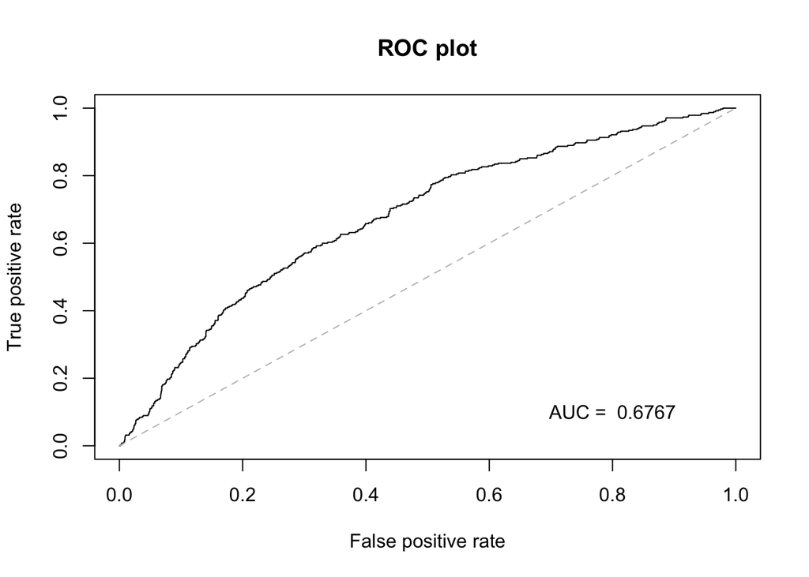

```r
# ROC curve
rocplot(PIAAC.reg$health_status_good, predict.glm(final7, PIAAC.reg, type = "response", na.action = na.omit), title = "ROC plot")
title(main = "ROC plot")
```

## Consider two additional predictors: literacy1 and Problem solving abilities

```r
full8 <- glm(health_status_good ~ numeracy1 + educ + income.cat +
               race + hisp + literacy1 + problem_solving1,
             data = PIAAC.reg, family = "binomial")
final8 <- step(full8, direction = "both", trace = 0)
# summary(final8)
fit8 <- glm(health_status_good ~ numeracy1 + educ + income.cat +
               literacy1 + problem_solving1, data = PIAAC.reg,
            family = "binomial")
# summary(final8)
multi_summary8 <- exp(cbind(coef(final8), confint(final8))[-1, ]) %>%
  as.data.frame()
colnames(multi_summary8)[1] <- "OR"
multi_summary8$sig <- ifelse(summary(final8)$coefficients[-1, 4] < 0.05, "*", "")

# power calculation
power8 <- powerSim(final8, nsim = 100, progress = FALSE)
auc8 <- auc(PIAAC.reg$health_status_good, predict.glm(final8, PIAAC.reg, type = "response", na.action = na.omit))
kable(multi_summary8) %>%
  kable_styling()
```

OR

2.5 %

97.5 %

sig

numeracy1

1.0143497

1.0078075

1.0209615

educSome college or associate’s degree

0.7923587

0.5855485

1.0635218

educBachelor’s degree or higher

0.5803978

0.4231802

0.7916286

income.cat$50k-$100k

0.5085231

0.3881148

0.6630423

income.cat$100k-$150k

0.3221426

0.2037698

0.4920902

income.cat$150k+

0.3459020

0.2088930

0.5506310

literacy1

0.9909213

0.9837965

0.9981147

problem_solving1

0.9867251

0.9815617

0.9918693

```r
# Calculate error rate
fit8.train <- glm(health_status_good ~ numeracy1 + educ + income.cat +
               problem_solving1, data = PIAAC.training,
            family = "binomial")
pred8 <- predict(fit8.train, PIAAC.test, type = "response")
pred8 <- ifelse(pred8 > .5, "Not Good", "Good")
err8 <- mean(pred8 != PIAAC.test$health_status_good)
```

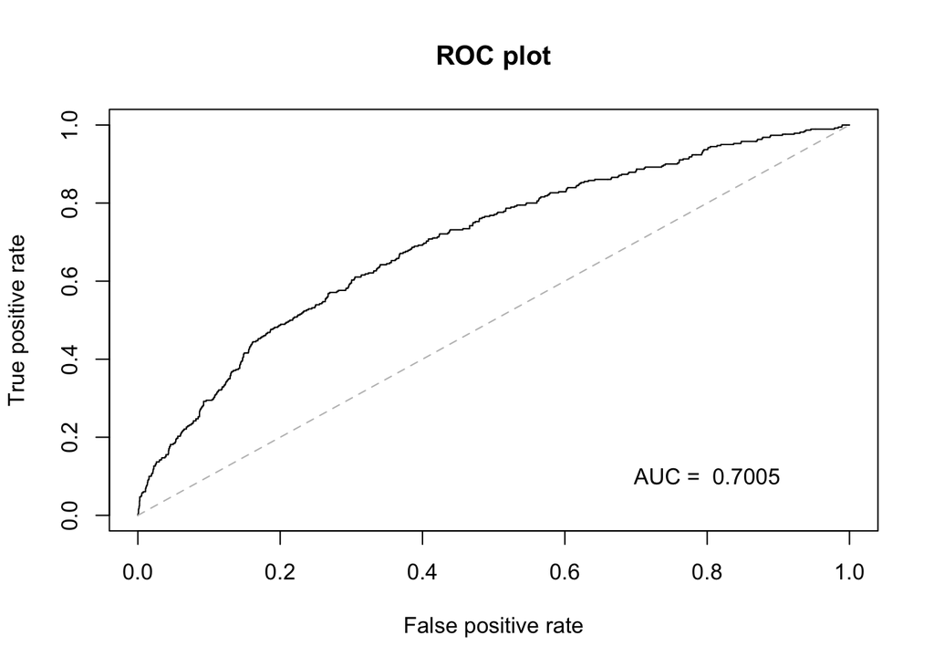

```r
rocplot(PIAAC.reg$health_status_good, predict.glm(final8, PIAAC.reg, type = "response", na.action = na.omit), title = "ROC plot")
title(main = "ROC plot")
```

# Summary

## ESP

```r
ESP_h1 <- c("health status: Good vs Not Good", "",
            round(auc1[1], 3),
            power1$x/power1$n, round(err1, 4), "\\*","", "\\*","\\*",
            "\\*","", "")
ESP_h2 <- c("health status: Good vs Not Good",
            "education, income", round(auc2[1], 3),
            power2$x/power2$n, round(err2, 4), "\\*", "", "\\*","\\*",
            "\\*","", "\\*")
ESP_h3 <- c("visits to doctors: Often vs Not Often", "",
            round(auc3[1], 3),
            "/", round(err3, 4), "","\\*", "\\*", "","\\*","", "\\*")
ESP_h4 <- c("visits to doctors: Often vs Not Often",
            "education, income",
            round(auc4[1], 3),
            "/", round(err4, 4), "","\\*", "\\*", "\\*","\\*","", "")
ESP.result <- data.frame(ESP_h1, ESP_h2, ESP_h3, ESP_h4) %>% t() %>% as.data.frame()
rownames(ESP.result) <- NULL
colnames(ESP.result) <- c("Outcome", "Adjusted covariates", "AUC", "Power", "Prediction Error Rate", "numeracy", "gender", "age", "educ", "income", "race", "hisp")
ESP.result %>%
  kable(caption = "ESP's multivariates regression summary") %>%
  kable_styling() %>%
  add_header_above(c("Response" = 1, "Weights" = 1, "Performance"=3,"Predictor"=1,"Covariates"=6))
```

ESP’s multivariates regression summary

| Response Outcome | Weights Adjusted covariates | Performance AUC | Performance Power | Performance Prediction Error Rate | Predictor numeracy | Covariates gender | Covariates age | Covariates educ | Covariates income | Covariates race | Covariates hisp |
| --- | --- | --- | --- | --- | --- | --- | --- | --- | --- | --- | --- |
| health status: Good vs Not Good |  | 0.724 | 0.81 | 0.219 | * |  | * | * | * |  |  |
| health status: Good vs Not Good | education, income | 0.72 | 0.574 | 0.219 | * |  | * | * | * |  | * |
| visits to doctors: Often vs Not Often |  | 0.643 | / | 0.3497 |  | * | * |  | * |  | * |
| visits to doctors: Often vs Not Often | education, income | 0.636 | / | 0.3725 |  | * | * | * | * |  |  |

## PIAAC - PV1

```r
PIAAC_h1 <- c("health status: Good vs Not Good", round(auc5[1], 3),
            power5$x/power5$n, round(err5, 4), "\\*","\\*", "\\*","", "","/", "/")
PIAAC_h2 <- c("health status: Good vs Not Good", round(auc6[1], 3),
            power6$x/power6$n, round(err6, 4), "\\*","\\*", "\\*","", "","\\*", "")

PIAAC.result <- data.frame(PIAAC_h1, PIAAC_h2) %>%
  t() %>%
  as.data.frame()
rownames(PIAAC.result) <- NULL
colnames(PIAAC.result) <- c("Outcome", "AUC", "Power", "Prediction Error Rate",
                        "numeracy", "educ", "income", "race",
                        "hisp", "problem solving", "literacy")
PIAAC.result %>%
  kable(caption = "PIAAC's multivariates regression summary - PV1") %>%
  kable_styling() %>%
  add_header_above(c("Response" = 1, "Performance"=3,"Predictor"=1,"Covariates"=4, "Additional Predictor" = 2))
```

PIAAC’s multivariates regression summary - PV1

| Response Outcome | Performance AUC | Performance Power | Performance Prediction Error Rate | Predictor numeracy | Covariates educ | Covariates income | Covariates race | Covariates hisp | Additional Predictor problem solving | Additional Predictor literacy |
| --- | --- | --- | --- | --- | --- | --- | --- | --- | --- | --- |
| health status: Good vs Not Good | 0.676 | 0.75 | 0.1475 | * | * | * |  |  | / | / |
| health status: Good vs Not Good | 0.69 | 0.77 | 0.1475 | * | * | * |  |  | * |  |

## PIAAC - mean of PVs

```r
PIAAC_h1 <- c("health status: Good vs Not Good", round(auc7[1], 3),
            power7$x/power7$n, round(err7, 4), "\\*","\\*", "\\*","", "","/", "/")
PIAAC_h2 <- c("health status: Good vs Not Good", round(auc8[1], 3),
            power8$x/power8$n, round(err8, 4), "\\*","\\*", "\\*","", "","\\*", "\\*")

PIAAC.result <- data.frame(PIAAC_h1, PIAAC_h2) %>%
  t() %>%
  as.data.frame()
rownames(PIAAC.result) <- NULL
colnames(PIAAC.result) <- c("Outcome", "AUC", "Power", "Prediction Error Rate",
                        "numeracy", "educ", "income", "race",
                        "hisp", "problem solving", "literacy")
PIAAC.result %>%
  kable(caption = "PIAAC's multivariates regression summary - PV mean") %>%
  kable_styling() %>%
  add_header_above(c("Response" = 1, "Performance"=3,"Predictor"=1,"Covariates"=4, "Additional Predictor" = 2))
```

PIAAC’s multivariates regression summary - PV mean

| Response Outcome | Performance AUC | Performance Power | Performance Prediction Error Rate | Predictor numeracy | Covariates educ | Covariates income | Covariates race | Covariates hisp | Additional Predictor problem solving | Additional Predictor literacy |
| --- | --- | --- | --- | --- | --- | --- | --- | --- | --- | --- |
| health status: Good vs Not Good | 0.677 | 0.75 | 0.1475 | * | * | * |  |  | / | / |
| health status: Good vs Not Good | 0.701 | 1 | 0.1466 | * | * | * |  |  | * | * |